# chromVAR

Gabriel Ascui

2022-07-08

# chromVAR pipeline

Applying chromVAR to ImmGen ATAC-seq dataset.

## loading libraries and mouse genome from Biostrings.

```r
#### libraries
library(chromVAR)
library(motifmatchr)
library(Matrix)
library(SummarizedExperiment)
library(BiocParallel)
library(TFBSTools)
set.seed(2022)
## extra libraries
library(tidyverse)
library(BSgenome.Mmusculus.UCSC.mm10)
```

```r
library(pheatmap)
library(RColorBrewer)
```

make sure you have all libraries installed and you have 8 cores to run parallel processes.

## Load data and metadata

Make sure to have correct encoding for count table `.csv` file.

```r
## read data
counts <- read.csv(file = "ImmGen_ATACseq_count_table.csv", sep = ",", check.names = FALSE, encoding = 'cp1252')
colnames(counts) <- gsub("\x96","", colnames(counts))
head(counts)
```

```
##                       PeakID   Chr    Start      End B.GC.CB.Sp#2 B.mem.Sp#1
## 1      ImmGenATAC1219.peak_1  chr1  3020661  3020911            0          1
## 2     ImmGenATAC1219.peak_10  chr1  3434253  3434503            2          2
## 3    ImmGenATAC1219.peak_100  chr1  4584164  4584414            1          1
## 4   ImmGenATAC1219.peak_1000  chr1 12958566 12958816            0          2
## 5  ImmGenATAC1219.peak_10000  chr1 64002962 64003212            1          1
## 6 ImmGenATAC1219.peak_100000 chr12 29176081 29176331            0          3
##   B.mem.Sp#2 B.PB.Sp#1 B.PC.Sp#1 B.PC.BM#1 B.PC.BM#2 B.Fo.Sp#3 preT.DN3.Th#2
## 1          0         3         0         1         4         1             1
## 2          0         2         1         0         0         0             0
## 3         10         0         2         2         1         3             1
## 4          1         3         0         0         0         1             0
## 5          1         1         0         1         0         1             1
## 6          0         1         0         1         1         1             2
##   B.Sp#3 B.Sp#4 NKT.Sp#3 NKT.Sp#4 NKT.Sp.LPS.3hr#1 NKT.Sp.LPS.3hr#2
```

[output cut: 251 more lines]

```r
counts %>% select(contains("Sp")) %>% glimpse()
```

```
## Rows: 512,595
## Columns: 73
## $ `B.GC.CB.Sp#2`            <int> 0, 2, 1, 0, 1, 0, 0, 1, 0, 0, 0, 0, 0, 1, 0,…
## $ `B.mem.Sp#1`              <int> 1, 2, 1, 2, 1, 3, 2, 0, 0, 1, 5, 1, 1, 2, 1,…
## $ `B.mem.Sp#2`              <int> 0, 0, 10, 1, 1, 0, 2, 0, 0, 0, 0, 1, 0, 0, 0…
## $ `B.PB.Sp#1`               <int> 3, 2, 0, 3, 1, 1, 1, 4, 2, 1, 4, 1, 2, 1, 0,…
## $ `B.PC.Sp#1`               <int> 0, 1, 2, 0, 0, 0, 1, 2, 2, 0, 1, 2, 0, 1, 4,…
## $ `B.Fo.Sp#3`               <int> 1, 0, 3, 1, 1, 1, 2, 1, 0, 0, 0, 0, 3, 0, 1,…
## $ `B.Sp#3`                  <int> 0, 0, 1, 1, 1, 2, 1, 3, 1, 0, 0, 2, 3, 3, 3,…
## $ `B.Sp#4`                  <int> 1, 1, 4, 0, 2, 1, 0, 0, 1, 0, 0, 0, 2, 0, 2,…
## $ `NKT.Sp#3`                <int> 0, 1, 0, 0, 0, 1, 2, 1, 0, 2, 2, 4, 0, 1, 0,…
## $ `NKT.Sp#4`                <int> 1, 1, 2, 0, 2, 2, 0, 1, 0, 4, 2, 2, 3, 1, 1,…
## $ `NKT.Sp.LPS.3hr#1`        <int> 0, 2, 2, 2, 0, 4, 2, 0, 3, 0, 1, 0, 2, 2, 2,…
## $ `NKT.Sp.LPS.3hr#2`        <int> 0, 0, 1, 2, 0, 0, 2, 0, 0, 1, 2, 0, 4, 3, 2,…
## $ `NKT.Sp.LPS.18hr#1`       <int> 1, 1, 0, 0, 0, 1, 0, 1, 1, 1, 1, 0, 1, 0, 0,…
```

[output cut: 60 more lines]

```r
## read metadata
metadata <- read.csv(file = "ImmGen_ATACseq_metadata.csv", sep = ",", nrows = 16)
```

## Counts and Peaks

```r
## building new index : bed file with first column as chromosome, second as start, and third as end.
## make in based on ImmGen_ATACseq_count_table.csv
##
index <- counts[,1:4]
index <- index[, c(2,3,4,1)]
head(index)
```

```
##     Chr    Start      End                     PeakID
## 1  chr1  3020661  3020911      ImmGenATAC1219.peak_1
## 2  chr1  3434253  3434503     ImmGenATAC1219.peak_10
## 3  chr1  4584164  4584414    ImmGenATAC1219.peak_100
## 4  chr1 12958566 12958816   ImmGenATAC1219.peak_1000
## 5  chr1 64002962 64003212  ImmGenATAC1219.peak_10000
## 6 chr12 29176081 29176331 ImmGenATAC1219.peak_100000
```

```r
colnames(index) <- c("chr", "start", "end", "peakid")
write.table(index, file = "new_index.bed", quote = FALSE, sep = "\t", row.names = FALSE, col.names = FALSE)
## read new index into peaks
peakfile = "new_index.bed"
peaks <- getPeaks(peakfile, sort_peaks = TRUE,
                  extra_cols = setNames(4,"peakid")
                  )
```

```
## Peaks sorted
```

```r
##
## filter important samples by metadata
counts_mtx <- counts %>% select(metadata$ID)
## make usable object
counts_mtx <- as.matrix(counts_mtx)
fragment_counts <- SummarizedExperiment(assays =
                                          list(counts = counts_mtx),
                                        colData = metadata,
                                        rowRanges = peaks
)
## GC content of peaks
fragment_counts <- addGCBias(fragment_counts, genome = BSgenome.Mmusculus.UCSC.mm10)
## filtering peaks
counts_filtered <- filterPeaks(fragment_counts, non_overlapping = TRUE)
```

## Motifs

```r
motifs <- getJasparMotifs() ## default is CORE
motif_ix <- matchMotifs(motifs, counts_filtered,
                        genome = BSgenome.Mmusculus.UCSC.mm10)
## background peaks
bg <- getBackgroundPeaks(object = counts_filtered)
## calculate deviation
dev <- computeDeviations(object = counts_filtered, annotations = motif_ix,
                         background_peaks = bg)
## variability
variability <- computeVariability(dev)
```

### plot variability

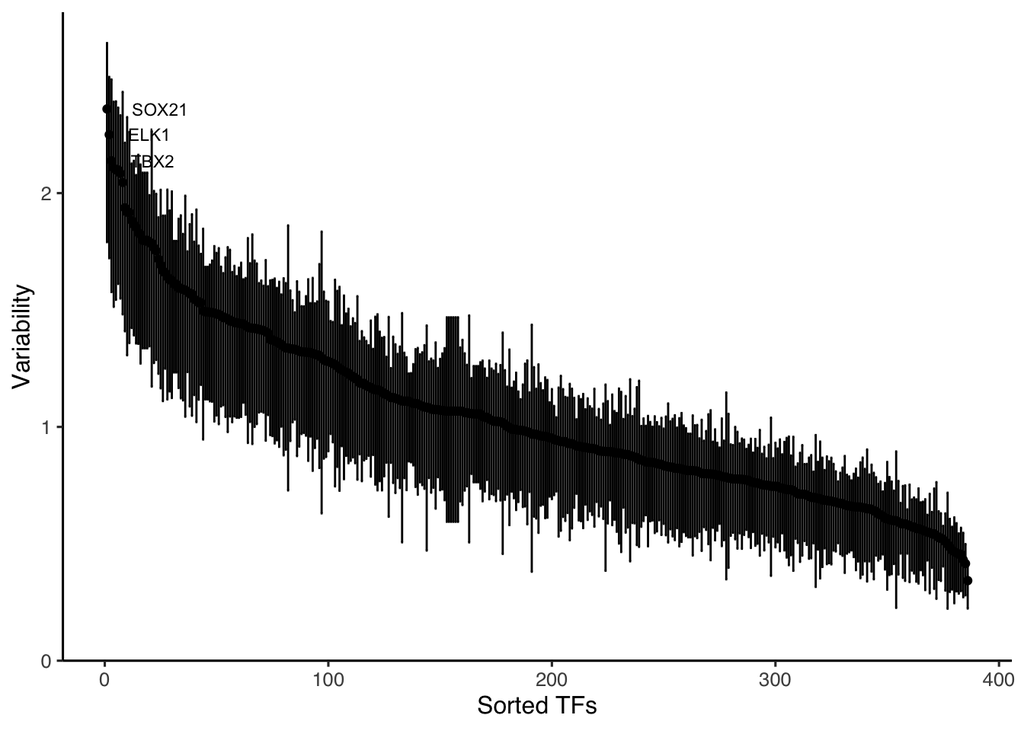

```r
plotVariability(variability, use_plotly = FALSE)
```

### plot deviation

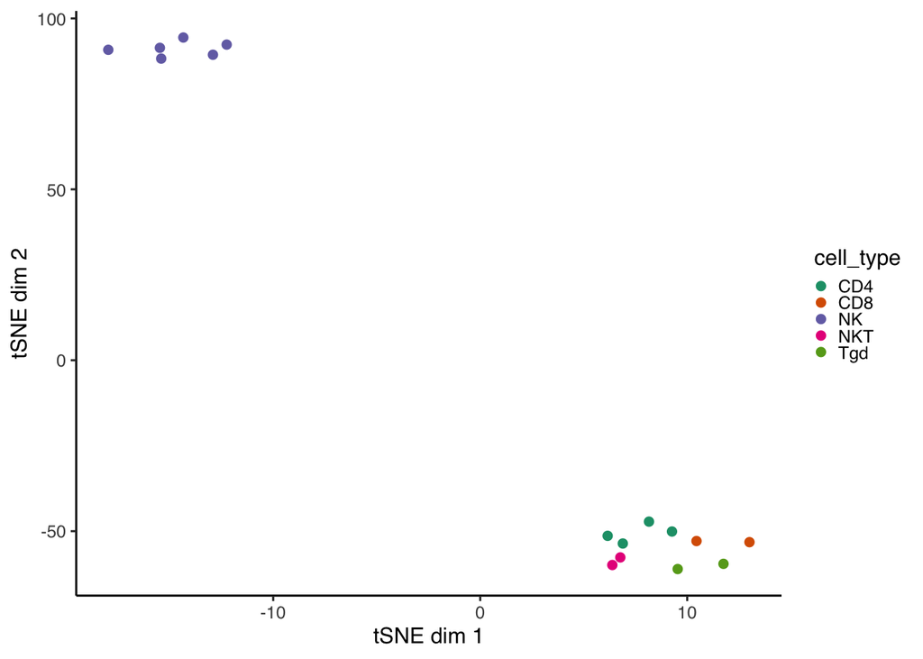

```r
## visualizing deviation
tsne_results <- deviationsTsne(dev, threshold = 1.5, perplexity = 5)
tsne_plots <- plotDeviationsTsne(dev, tsne_results,
                                 annotation_name = "FOS::JUN",
                                 sample_column = "cell_type",
                                 shiny = FALSE)
tsne_plots[[1]]
```

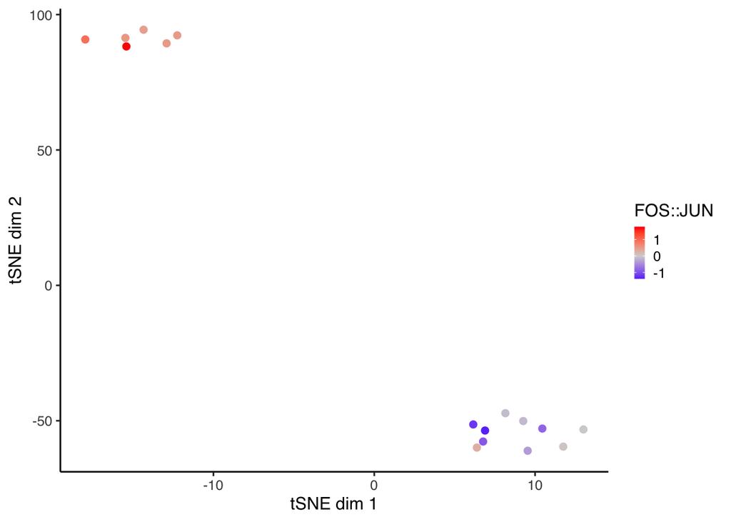

```r
ggsave(last_plot(), filename = "tsne_deviation_rmd.pdf")
tsne_plots[[2]]
```

```r
ggsave(last_plot(), filename = "tsne_deviation_FosJun_rmd.pdf")
```

### MORE STUFF

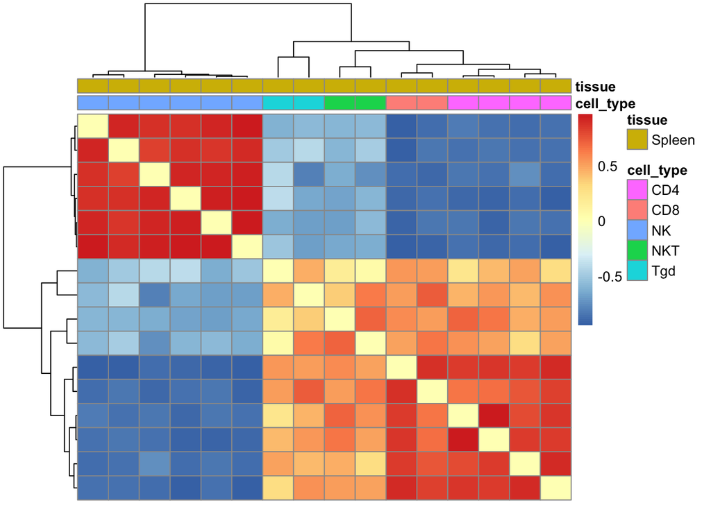

```r
## clustering
sample_cor <- getSampleCorrelation(dev)
pheatmap(as.dist(sample_cor),
         annotation_col = as.data.frame(colData(dev))[,-c(1)],
         clustering_distance_rows = as.dist(1-sample_cor),
         clustering_distance_cols = as.dist(1-sample_cor)
         )
```

```r
## differential accessibility and variability
diff_acc <- differentialDeviations(dev, "cell_type")
head(diff_acc)
```

```
##                          p_value p_value_adjusted
## MA0025.1_NFIL3       0.020424336       0.05873858
## MA0030.1_FOXF2       0.009035841       0.04607836
## MA0031.1_FOXD1       0.014843654       0.05115759
## MA0051.1_IRF2        0.481159675       0.50745255
## MA0056.1_MZF1        0.021401917       0.05986333
## MA0057.1_MZF1(var.2) 0.021685533       0.06008016
```

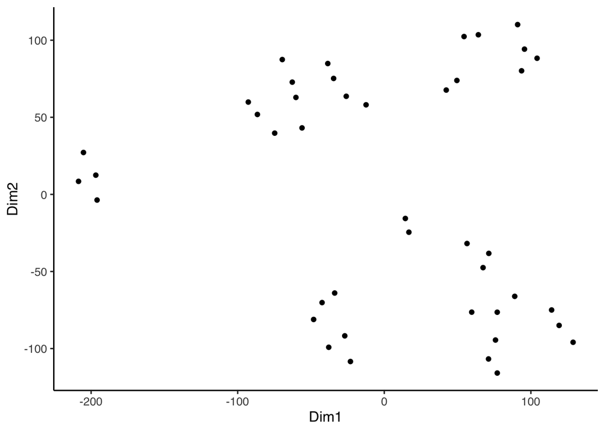

```r
### tSNE for Motifs (not sure what this is useful for...)
inv_tsne_results <- deviationsTsne(dev, threshold = 1.5, perplexity = 3,
                                   what = "annotations", shiny = FALSE)
ggplot(inv_tsne_results, aes(x = Dim1, y = Dim2)) + geom_point() +
  chromVAR_theme()
```

```r
### Motif synergy
msin <- getAnnotationSynergy(counts_filtered, motif_ix[,c(1,2,3)])
msin
```

```
##                MA0031.1_FOXD1 MA0025.1_NFIL3 MA0030.1_FOXF2
## MA0031.1_FOXD1      0.0000000      1.8668143      0.2835662
## MA0025.1_NFIL3      1.8668143      0.0000000     -0.6528297
## MA0030.1_FOXF2      0.2835662     -0.6528297      0.0000000
```

```r
## Motif
mcor <- getAnnotationCorrelation(counts_filtered, motif_ix[,c(1,2,3)])
mcor
```

```
##                MA0025.1_NFIL3 MA0031.1_FOXD1 MA0030.1_FOXF2
## MA0025.1_NFIL3      1.0000000      0.2747695      0.4666349
## MA0031.1_FOXD1      0.2747695      1.0000000     -0.1295344
## MA0030.1_FOXF2      0.4666349     -0.1295344      1.0000000
```

### differential expression of TFs motifs using deviation (z-scores)

Using same analysis as in **Murray et al. 2021**.

> *chromVAR computed deviation in ATAC-seq signal (Z-score) at regions containing indicated transcription factor motifs between the indicated cell populations from spleen and lung. Motifs with a p-value less than 1e-25 are shown and families and representative members are labeled.*

```r
## here is the data that I need to make pheatmap
dev_table <- as.data.frame(dev@assays@data@listData$z)
## callback
callback = function(hc, mat){
    sv = svd(t(mat))$v[,1]
    dend = reorder(as.dendrogram(hc), wts = sv)
    as.hclust(dend)
}
## hclust for TFs row annotations
hclust <- hclust(dist(dev_table[diff_acc$p_value_adjusted < 0.05,]), method = "complete")
tf_col <- cutree(tree = hclust, k = 6) ## 6 clusters, one for each cell_type
tf_col <- data.frame(cluster = ifelse(tf_col == 1, "c1",
                                      ifelse(tf_col == 2, "c2",
                                             ifelse(tf_col == 3, "c3",
                                                    ifelse(tf_col == 4, "c4",
                                                           ifelse(tf_col == 5, "c5", "c6"))))))
## metadata for celltype column annotations
cell_row <- data.frame(row.names = metadata$ID, metadata$cell_type)
cell_row$metadata.cell_type <- factor(cell_row$metadata.cell_type, levels = c("NK","NKT","Tgd","CD8","CD4"))
cell_row <- arrange(cell_row, metadata.cell_type)
## reorder by cell_type
dev_table <- dev_table[,rownames(cell_row)]
## add metadata to each motif
mlist <- motifs@listData[names(motifs)]
mlist <- lapply(mlist, function(x) slot(x, "tags"))
motifs_df <- map_dfr(mlist, ~as_tibble(t(.)))
rownames(motifs_df) <- names(mlist)
motifs_big <- cbind(dev_table,motifs_df, diff_acc) #row.names(dev_table) == row.names(motifs_df)
### only TFs with high sd values ?
#hist(rowSds(as.matrix(dev_table)))
#table(unlist(motifs_big$family))
tf_col$family <- motifs_big[diff_acc$p_value_adjusted < 0.05,]$family
tf_col$family <- as.data.frame(do.call(rbind,tf_col$family))[1]
tf_col$family <- tf_col$family$V1
tf_col$family <- gsub("[^ -~]","u",tf_col$family) ## offending character
```

Make `pheatmap` for all motifs.

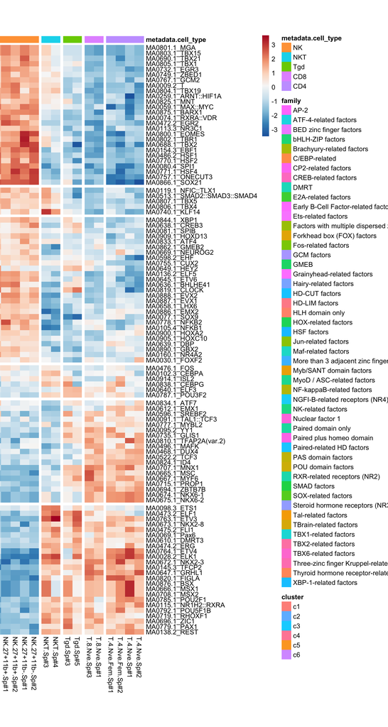

```r
## plot
pheatmap(-dev_table[diff_acc$p_value_adjusted < 0.05,], ## filter significant differential deviation
         color = colorRampPalette(rev(brewer.pal(9,"RdBu")))(255),
         border_color = NA,
         cellheight = 8, cellwidth = 14,
         width = 20, height = 25,
         annotation_row = tf_col,
         annotation_col = cell_row,
         clustering_callback = callback,
         cluster_cols = FALSE,
         #filename = "motifs_heatmap.pdf",
         cutree_rows = 6,
         gaps_col = c(6,8,10,12)
         )
```

```r
## make pdf file
pheatmap(-dev_table[diff_acc$p_value_adjusted < 0.05,], ## filter significant differential deviation
         color = colorRampPalette(rev(brewer.pal(9,"RdBu")))(255),
         border_color = NA,
         cellheight = 8, cellwidth = 14,
         width = 20, height = 25,
         annotation_row = tf_col,
         annotation_col = cell_row,
         clustering_callback = callback,
         cluster_cols = FALSE,
         filename = "motifs_heatmap.pdf",
         cutree_rows = 6,
         gaps_col = c(6,8,10,12)
         )
```

Need to do new `pheatmap` with averages per cell type.

```r
mlist <- list()
for(l in levels(cell_row$metadata.cell_type)) {
  mlist[[l]] <- rowSums(dev_table[,rownames(cell_row)[cell_row$metadata.cell_type==l]]) / length(rownames(cell_row)[cell_row$metadata.cell_type==l])
}
mdf <- as.data.frame(mlist)

mdf[tf_col$family=="TBX2-related factors",]
```

```
##                                NK        NKT          Tgd          CD8
## MA0478.1_FOSL2        0.148813921 -0.4776223 -0.323774712  0.003473697
## MA0140.2_GATA1::TAL1  0.140713098  0.5061222 -0.001189784 -0.350062376
## MA0093.2_USF1        -0.305302984 -0.9097559  0.149083040  0.784266812
## MA0674.1_NKX6-1       1.371191457  0.3360338  0.300762283 -1.335814640
## MA0132.2_PDX1        -0.058955509  1.5649886 -0.494694872 -0.005893487
## MA0713.1_PHOX2A       0.390065234  0.9516728 -0.540226018 -0.559073702
## MA0498.2_MEIS1        0.009249002  0.5014441 -0.038471522  0.441866197
## MA0807.1_TBX5        -1.006787368 -0.9748521  0.573861533  1.305144805
## MA0808.1_TEAD3        1.184537907  0.9992740 -0.475403727 -1.200410791
## MA0886.1_EMX2        -0.896550354  2.6174507  1.067356699  0.890832557
##                             CD4
## MA0478.1_FOSL2        0.2278490
## MA0140.2_GATA1::TAL1 -0.2076665
## MA0093.2_USF1         0.3768233
## MA0674.1_NKX6-1      -1.9119235
## MA0132.2_PDX1        -0.2447954
## MA0713.1_PHOX2A      -0.5500847
## MA0498.2_MEIS1       -0.5482004
## MA0807.1_TBX5         1.1168919
## MA0808.1_TEAD3       -1.4492825
## MA0886.1_EMX2        -0.1666043
```

#### Get new family of TFs

Make `pheatmap` with group of family of TFs motifs.

Data from **Lambert SA, Jolma A, Campitelli LF, Das PK, Yin Y, Albu M, Chen X, Taipale J, Hughes TR, Weirauch MT.(2018) The Human Transcription Factors. Cell. 172(4):650-665. doi: 10.1016/j.cell.2018.01.029. Review.**

```r
## http://humantfs.ccbr.utoronto.ca/download.php
## Lambert SA, Jolma A, Campitelli LF, Das PK, Yin Y, Albu M, Chen X, Taipale J, Hughes TR, Weirauch MT.(2018) The Human Transcription Factors. Cell. 172(4):650-665. doi: 10.1016/j.cell.2018.01.029. Review.
tf_dbd <- read.table("DatabaseExtract_v_1.01.csv", sep = ",", header = TRUE, fill = TRUE)
## only going to take first TF and only var 1
tf <- gsub("::.*","", gsub("\\(var\\.\\d\\)","", gsub(".*_","",rownames(mdf))))
tf_f <- data.frame(symbol = tf)
tf_f <- merge(tf_dbd[tf_dbd$HGNC.symbol %in% tf_f$symbol,][c("HGNC.symbol","DBD")],
              tf_f,
              by.x = "HGNC.symbol",
              by.y = "symbol")
tf_f <- tf_f[match(tf,tf_f$HGNC.symbol),]
rownames(tf_f) <- rownames(mdf)
tf_col <- data.frame(family = tf_f$DBD)
rownames(tf_col) <- rownames(mdf)
## pheatmap
for (f in names(table(tf_col)[table(tf_col) > 2])) {
  tryCatch({
    pheatmap(-mdf[diff_acc$p_value_adjusted < 0.05 & ifelse(is.na(tf_col$family == f),FALSE,tf_col$family == f),],
         cluster_cols = FALSE,
         #cutree_rows = if (dim(-mdf[diff_acc$p_value_adjusted < 0.05 & ifelse(is.na(tf_col$family == f),FALSE,tf_col$family == f),])[1] < 2) 1 else 6,
         clustering_callback = callback,
         #cluster_rows = FALSE,
         cluster_rows = if (dim(-mdf[diff_acc$p_value_adjusted < 0.05 & ifelse(is.na(tf_col$family == f),FALSE,tf_col$family == f),])[1] < 2) FALSE else TRUE,
         #annotation_row = tf_col,
         #labels_row = tf_f$HGNC.symbol
         filename = paste0(f,"_heatmap",".pdf")
         )
  }, error=function(e){cat("ERROR :", conditionMessage(e),"\n")})
}
```

[output not shown]

[output not shown]

[output not shown]

[output not shown]

[output not shown]

[output not shown]

[output not shown]

[output not shown]

[output not shown]

Try same for individual samples

```r
### loop
for (f in names(table(tf_col)[table(tf_col) > 2])) {
  tryCatch({
    pheatmap(-dev_table[diff_acc$p_value_adjusted < 0.05 & ifelse(is.na(tf_col$family == f),FALSE,tf_col$family == f),],
         cluster_cols = FALSE,
         #cutree_rows = if (dim(-mdf[diff_acc$p_value_adjusted < 0.05 & ifelse(is.na(tf_col$family == f),FALSE,tf_col$family == f),])[1] < 2) 1 else 6,
         clustering_callback = callback,
         #cluster_rows = FALSE,
         cluster_rows = if (dim(-mdf[diff_acc$p_value_adjusted < 0.05 & ifelse(is.na(tf_col$family == f),FALSE,tf_col$family == f),])[1] < 2) FALSE else TRUE,
         #annotation_row = tf_col,
         #labels_row = tf_f$HGNC.symbol
         filename = paste0(f,"_all_heatmap",".pdf")
         )
  }, error=function(e){cat("ERROR :", conditionMessage(e),"\n")})
}
```

[output not shown]

[output not shown]

[output not shown]

[output not shown]

[output not shown]

[output not shown]

[output not shown]

[output not shown]

[output not shown]

## Tracks for specific TFs

First we need to generate a list of regulatory objects close to gene of interest.

> > Load UCSC libraries & `biomaRt`

Use `BiomaRt` to retrieve ENSMUST00000 code to location in genome

```r
## TSS location per each gene (grep for specific gene) according to UCSC
ucscGenesActive <- read.table("Mm_ucscTSS_mm10.sga", as.is=T, sep="\t", header=F) ### TSS location
## load biomaRt
library(biomaRt)
## connect to mart for transcripts and for regulatory elements
mart <- useMart("ENSEMBL_MART_ENSEMBL", dataset = "mmusculus_gene_ensembl") ## this takes time
mart_reg <- useMart("ENSEMBL_MART_FUNCGEN", dataset = "mmusculus_regulatory_feature") ## mmusculus_regulatory_feature
```

```
## Ensembl site unresponsive, trying uswest mirror
```

```r
# listMarts() ## ENSEMBL_MART_FUNCGEN
# listDatasets(mart_reg)  ## mmusculus_regulatory_feature
# listAttributes(mart_reg)
## read GFF
# V1 is chromosome_name
# V2 is library
# V3 is feature_type_name
# V9 is summary with ID (grep ID) with ENSMUSR code
encode_gff <- read.delim("mus_musculus.GRCm39.Regulatory_Build.regulatory_features.20201021.gff", header=F, comment.char="#")
```

> There are other libraries and SQL files we can use, but we will stick with ENSEMBL.

Actual code:

```r
gene = "Tbx21"
## find TSS
ucscGenesActive[grep(gene, x = ucscGenesActive$V6),] ## V3 has the TSS location V6 has transcript ID for ensembl
```

```
##                V1  V2       V3 V4 V5                        V6
## 22959 NC_000077.6 TSS 97115331  -  1 ENSMUST00000001484..Tbx21
```

```r
gene_id <- gsub("\\.\\..*","",  ucscGenesActive[grep(gene, x = ucscGenesActive$V6),]$V6 )
## find chrmosome_name and relative location of gene
mart_results <- getBM(filters= "ensembl_transcript_id",
                attributes= c("ensembl_transcript_id",
                              "ensembl_gene_id",
                              "mgi_symbol",
                              "chromosome_name",
                              "strand",
                              "start_position",
                              "end_position"),
                values=gene_id,
                mart= mart)
#mart_results
gene_results <- data.frame(
  gene_symbol = mart_results$mgi_symbol,
  ensembl_gene_id = mart_results$ensembl_gene_id,
  tss_location = ucscGenesActive[grep(gene, x = ucscGenesActive$V6),]$V3,
  chromosome_name = mart_results$chromosome_name,
  strand = mart_results$strand,
  start_position = mart_results$start_position,
  end_position = mart_results$end_position
)
#encode_gff[grep("ENSMUSR00000784626",encode_gff$V9),]
#head(encode_gff)  ## V9 has ID=open_chromatin_region:ENSMUSR
#table(encode_gff$V1)
### final table
reg_regions <- encode_gff[encode_gff$V1 == gene_results$chromosome_name & encode_gff$V4 > gene_results$start_position & encode_gff$V5 < gene_results$end_position+10000,]
reg_regions
```

```
##        V1               V2                       V3       V4       V5 V6 V7 V8
## 236182 11 Regulatory_Build        CTCF_binding_site 96992401 96993000  .  .  .
## 236183 11 Regulatory_Build        CTCF_binding_site 97014001 97014400  .  .  .
## 245676 11 Regulatory_Build                 promoter 97005200 97006801  .  .  .
## 250723 11 Regulatory_Build promoter_flanking_region 96992449 96993200  .  .  .
## 250724 11 Regulatory_Build promoter_flanking_region 96993908 96994688  .  .  .
## 250725 11 Regulatory_Build promoter_flanking_region 97004201 97004400  .  .  .
##                                                                                                                                                                                 V9
## 236182                                ID=CTCF_binding_site:ENSMUSR00000324719;bound_end=96993000;bound_start=96992401;description=CTCF Binding Site;feature_type=CTCF Binding Site
## 236183                                ID=CTCF_binding_site:ENSMUSR00000324724;bound_end=97014400;bound_start=97014001;description=CTCF Binding Site;feature_type=CTCF Binding Site
## 245676                                                 ID=promoter:ENSMUSR00000784626;bound_end=97040999;bound_start=97004602;description=Predicted promoter;feature_type=Promoter
## 250723 ID=promoter_flanking_region:ENSMUSR00000784623;bound_end=96993200;bound_start=96992449;description=Predicted promoter flanking region;feature_type=Promoter Flanking Region
## 250724 ID=promoter_flanking_region:ENSMUSR00000784624;bound_end=96994688;bound_start=96993908;description=Predicted promoter flanking region;feature_type=Promoter Flanking Region
## 250725 ID=promoter_flanking_region:ENSMUSR00000784625;bound_end=97004400;bound_start=97004201;description=Predicted promoter flanking region;feature_type=Promoter Flanking Region
```

Use `gene_results` and `reg_regions` to generate trackplots() accordingly for each cell type ATAC-seq data in bigWig files.

```r
source("trackplot.R")
# brew install mysql
# install perl requirements
#
## Pohl A, Beato M. bwtool: a tool for bigWig files. Bioinformatics. 2014 Jun 1;30(11):1618-9. doi: 10.1093/bioinformatics/btu056. Epub 2014 Jan 30. PMID: 24489365; PMCID: PMC4029031.
#Path to bigWig files
bigWigs = c("/Volumes/BioAdHoc/Groups/KronenbergLab/gascui/innateness-analysis/atac_seq/immgen_data/GSE100738_NK.27-11b+.Sp.bw",
            "/Volumes/BioAdHoc/Groups/KronenbergLab/gascui/innateness-analysis/atac_seq/immgen_data/GSE100738_NKT.Sp.bw",
            "/Volumes/BioAdHoc/Groups/KronenbergLab/gascui/innateness-analysis/atac_seq/immgen_data/GSE100738_Tgd.Sp.bw",
            "/Volumes/BioAdHoc/Groups/KronenbergLab/gascui/innateness-analysis/atac_seq/immgen_data/GSE100738_T.8.Nve.Sp.bw",
            "/Volumes/BioAdHoc/Groups/KronenbergLab/gascui/innateness-analysis/atac_seq/immgen_data/GSE100738_T.4.Nve.Sp.bw"
            )
# Extract the signal for your loci of interest ## T-bet on chr11:97,020,000-96,985,000
track_data = track_extract(bigWigs = bigWigs,
                           loci = paste0("chr",
                                         gene_results$chromosome_name,
                                         ":",
                                         if(gene_results$strand == -1) {
                                           paste(gene_results$start_position)
                                           } else {
                                             paste(gene_results$start_position+10000)},
                                         "-",
                                         if(gene_results$strand == -1) {
                                           paste(gene_results$end_position+10000)
                                           } else {
                                             paste(gene_results$end_position)}))# "chr11:97,000,897-97,020,157"
```

```
## Checking for bwtool installation
```

```
##     All good! Found bwtool at: /usr/local/bin/bwtool
```

```
## Parsing loci..
```

```
##     Queried region: chr11:96988897-97016157 [27260 bps]
```

```
## Checking for files..
```

```
## Generating windows [50 bp window size]
```

```
## Extracting signals
```

```
##     Processing GSE100738_NK.27-11b+.Sp ..
```

```
##     Processing GSE100738_NKT.Sp ..
```

```
##     Processing GSE100738_Tgd.Sp ..
```

```
##     Processing GSE100738_T.8.Nve.Sp ..
```

```
##     Processing GSE100738_T.4.Nve.Sp ..
```

```r
### add names to each dataset.
track_data = track_summarize(summary_list = track_data, condition = c("1 NK cells", "2 NKT cells", "3 gd T cells", "4 CD8 T cells", "5 CD4 T cells"), stat = "mean")
#Basic Plot
#track_plot(summary_list = track_data, build = "mm39")
## Highlight regions of interest
markregions <- reg_regions
colnames(markregions)[c(3,4,5)] <- c("name","start","end")
markregions$chr <- paste0("chr",markregions$V1)
markregions %>% dplyr::select(chr, start,end,name) -> markregions
markregions
```

```
##          chr    start      end                     name
## 236182 chr11 96992401 96993000        CTCF_binding_site
## 236183 chr11 97014001 97014400        CTCF_binding_site
## 245676 chr11 97005200 97006801                 promoter
## 250723 chr11 96992449 96993200 promoter_flanking_region
## 250724 chr11 96993908 96994688 promoter_flanking_region
## 250725 chr11 97004201 97004400 promoter_flanking_region
```

```
## Missing gene model. Trying to query UCSC genome browser..
```

```
## Checking for mysql installation
```

```
##     All good! Found mysql at: /usr/local/bin/mysql
```

```
## Extracting gene models from UCSC:
##     chromosome: chr11
##     build: mm39
##     query: mysql --user genome --host genome-mysql.cse.ucsc.edu -NAD mm39 -e 'select chrom, txStart, txEnd, strand, name, name2, exonStarts, exonEnds from refGene WHERE chrom ="chr11"'
```

```
## Collapsing transcripts..
```

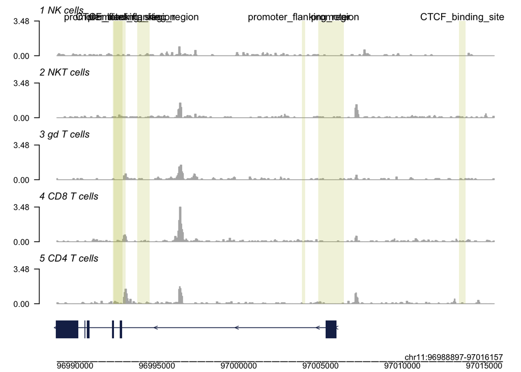

```r
## run track plot
track_plot(
  summary_list = track_data,
  draw_gene_track = TRUE,
  #show_ideogram = TRUE,
  build = "mm39",
  regions = markregions,
  boxcol = "#BEC446",
  genename = gene_results$gene_symbol
)
```